# 02 Session: Data Visualizations

Sergio Uribe

This code at the beginning tells all others not to show warnings or messages

# Review

Shortcuts

CTRL + ALT + I

ALT + -

CTRL + ALT + I

```
   Min. 1st Qu.  Median    Mean 3rd Qu.    Max.
   1.00   13.25   25.50   25.50   37.75   50.00
```

Beautify your code

CTRL + SHIFT + A

# Explore the dataset

| species | island | bill_length_mm | bill_depth_mm | flipper_length_mm | body_mass_g | sex | year |
| --- | --- | --- | --- | --- | --- | --- | --- |
| Adelie | Torgersen | 39.1 | 18.7 | 181 | 3750 | male | 2007 |
| Adelie | Torgersen | 39.5 | 17.4 | 186 | 3800 | female | 2007 |
| Adelie | Torgersen | 40.3 | 18.0 | 195 | 3250 | female | 2007 |
| Adelie | Torgersen | NA | NA | NA | NA | NA | 2007 |
| Adelie | Torgersen | 36.7 | 19.3 | 193 | 3450 | female | 2007 |
| Adelie | Torgersen | 39.3 | 20.6 | 190 | 3650 | male | 2007 |
| Adelie | Torgersen | 38.9 | 17.8 | 181 | 3625 | female | 2007 |
| Adelie | Torgersen | 39.2 | 19.6 | 195 | 4675 | male | 2007 |
| Adelie | Torgersen | 34.1 | 18.1 | 193 | 3475 | NA | 2007 |
| Adelie | Torgersen | 42.0 | 20.2 | 190 | 4250 | NA | 2007 |

[output cut: 334 more lines]

```
[1] 344   8
```

| species | island | bill_length_mm | bill_depth_mm | flipper_length_mm | body_mass_g | sex | year |
| --- | --- | --- | --- | --- | --- | --- | --- |
| Adelie | Torgersen | 39.1 | 18.7 | 181 | 3750 | male | 2007 |
| Adelie | Torgersen | 39.5 | 17.4 | 186 | 3800 | female | 2007 |
| Adelie | Torgersen | 40.3 | 18.0 | 195 | 3250 | female | 2007 |
| Adelie | Torgersen | NA | NA | NA | NA | NA | 2007 |
| Adelie | Torgersen | 36.7 | 19.3 | 193 | 3450 | female | 2007 |
| Adelie | Torgersen | 39.3 | 20.6 | 190 | 3650 | male | 2007 |

| species | island | bill_length_mm | bill_depth_mm | flipper_length_mm | body_mass_g | sex | year |
| --- | --- | --- | --- | --- | --- | --- | --- |
| Chinstrap | Dream | 45.7 | 17.0 | 195 | 3650 | female | 2009 |
| Chinstrap | Dream | 55.8 | 19.8 | 207 | 4000 | male | 2009 |
| Chinstrap | Dream | 43.5 | 18.1 | 202 | 3400 | female | 2009 |
| Chinstrap | Dream | 49.6 | 18.2 | 193 | 3775 | male | 2009 |
| Chinstrap | Dream | 50.8 | 19.0 | 210 | 4100 | male | 2009 |
| Chinstrap | Dream | 50.2 | 18.7 | 198 | 3775 | female | 2009 |

```
      species          island    bill_length_mm  bill_depth_mm
 Adelie   :152   Biscoe   :168   Min.   :32.10   Min.   :13.10
 Chinstrap: 68   Dream    :124   1st Qu.:39.23   1st Qu.:15.60
 Gentoo   :124   Torgersen: 52   Median :44.45   Median :17.30
                                 Mean   :43.92   Mean   :17.15
                                 3rd Qu.:48.50   3rd Qu.:18.70
                                 Max.   :59.60   Max.   :21.50
                                 NA's   :2       NA's   :2
 flipper_length_mm  body_mass_g       sex           year
 Min.   :172.0     Min.   :2700   female:165   Min.   :2007
 1st Qu.:190.0     1st Qu.:3550   male  :168   1st Qu.:2007
 Median :197.0     Median :4050   NA's  : 11   Median :2008
 Mean   :200.9     Mean   :4202                Mean   :2008
 3rd Qu.:213.0     3rd Qu.:4750                3rd Qu.:2009
 Max.   :231.0     Max.   :6300                Max.   :2009
 NA's   :2         NA's   :2
```

To access one specific variable, use the dollar sign

```
   Min. 1st Qu.  Median    Mean 3rd Qu.    Max.    NA's
  13.10   15.60   17.30   17.15   18.70   21.50       2
```

Check the class of the variables

```
[1] "integer"
```

# Types of variables in R

```
Rows: 344
Columns: 8
$ species           <fct> Adelie, Adelie, Adelie, Adelie, Adelie, Adelie…
$ island            <fct> Torgersen, Torgersen, Torgersen, Torgersen, To…
$ bill_length_mm    <dbl> 39.1, 39.5, 40.3, NA, 36.7, 39.3, 38.9, 39.2, …
$ bill_depth_mm     <dbl> 18.7, 17.4, 18.0, NA, 19.3, 20.6, 17.8, 19.6, …
$ flipper_length_mm <int> 181, 186, 195, NA, 193, 190, 181, 195, 193, 19…
$ body_mass_g       <int> 3750, 3800, 3250, NA, 3450, 3650, 3625, 4675, …
$ sex               <fct> male, female, female, NA, female, male, female…
$ year              <int> 2007, 2007, 2007, 2007, 2007, 2007, 2007, 2007…
```

*fct* : factors, can be nominal with two levels (as male, female) or more categories. By default R try to order the levels, from 1 and on or A and on.

*int* : integer numbers *dbl* : any number, even with decimals

Other types *logical* *date*

You can change the class of a variable

```
[1] "integer"
```

```
   Min. 1st Qu.  Median    Mean 3rd Qu.    Max.
   2007    2007    2008    2008    2009    2009
```

Useless, so we can change the variable

```
[1] "factor"
```

```
2007 2008 2009
 110  114  120
```

# Data visualizations

## The grammar of graphics

Three things: 1. Data 1. the mapping of the aesthetics elements, and 1. one or more geoms to visualize the data in the mappings

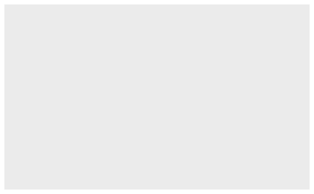

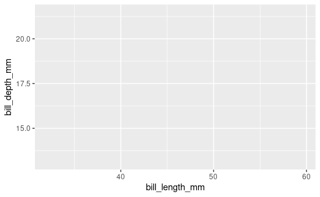

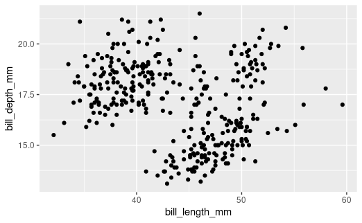

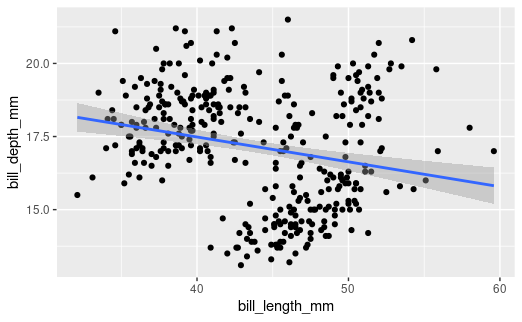

What can be concluded with the visualization of the correlation between the bill depth and bill length?

### The Simpson Paradox

Add more layers of information

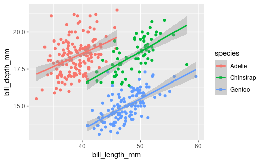

## Data Wrangling

| species |
| --- |
| Adelie |
| Adelie |
| Adelie |
| Adelie |
| Adelie |
| Adelie |
| Adelie |
| Adelie |
| Adelie |
| Adelie |

[output cut: 334 more lines]

| species | island | bill_length_mm | bill_depth_mm | flipper_length_mm | body_mass_g | sex | year |
| --- | --- | --- | --- | --- | --- | --- | --- |
| Adelie | Torgersen | 39.1 | 18.7 | 181 | 3750 | male | 2007 |
| Adelie | Torgersen | 39.5 | 17.4 | 186 | 3800 | female | 2007 |
| Adelie | Torgersen | 40.3 | 18.0 | 195 | 3250 | female | 2007 |
| Adelie | Torgersen | NA | NA | NA | NA | NA | 2007 |
| Adelie | Torgersen | 36.7 | 19.3 | 193 | 3450 | female | 2007 |
| Adelie | Torgersen | 39.3 | 20.6 | 190 | 3650 | male | 2007 |
| Adelie | Torgersen | 38.9 | 17.8 | 181 | 3625 | female | 2007 |
| Adelie | Torgersen | 39.2 | 19.6 | 195 | 4675 | male | 2007 |
| Adelie | Torgersen | 34.1 | 18.1 | 193 | 3475 | NA | 2007 |
| Adelie | Torgersen | 42.0 | 20.2 | 190 | 4250 | NA | 2007 |

[output cut: 142 more lines]

## DISTRIBUTIONS

### Distribucions: geom_histogram

What is the weight of the penguins?

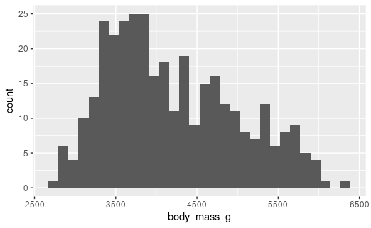

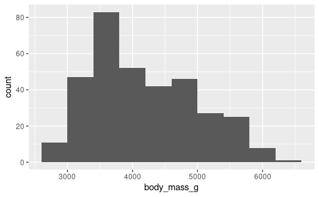

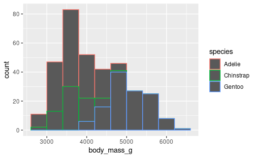

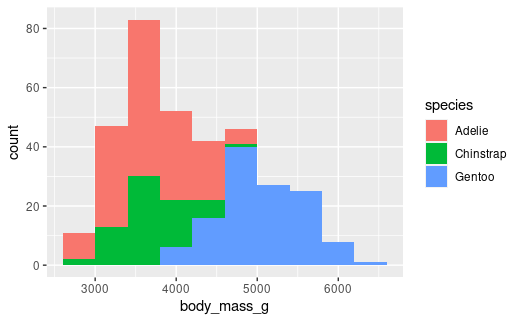

### Facetting

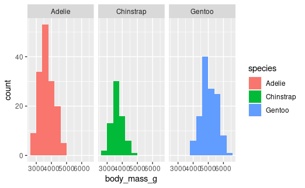

More control

facet_grid

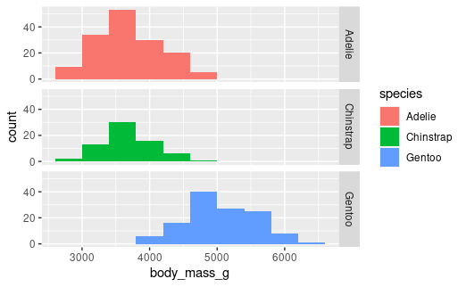

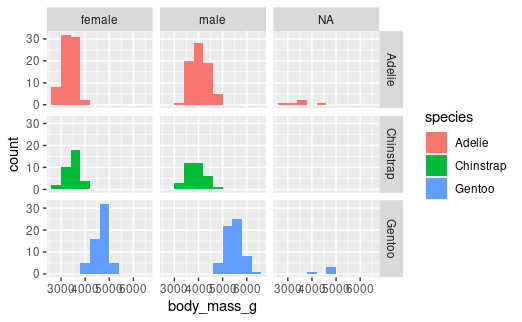

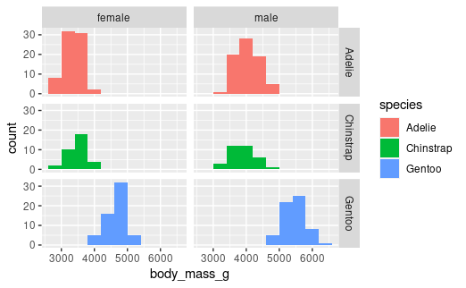

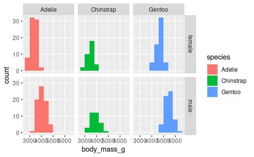

###EXERCISE DATA EXPLORATION AND HISTOGRAMS

Load NHANES

| ID | SurveyYr | Gender | Age | AgeDecade | AgeMonths | Race1 | Race3 | Education | MaritalStatus | HHIncome | HHIncomeMid | Poverty | HomeRooms | HomeOwn | Work | Weight | Length | HeadCirc | Height | BMI | BMICatUnder20yrs | BMI_WHO | Pulse | BPSysAve | BPDiaAve | BPSys1 | BPDia1 | BPSys2 | BPDia2 | … |
| --- | --- | --- | --- | --- | --- | --- | --- | --- | --- | --- | --- | --- | --- | --- | --- | --- | --- | --- | --- | --- | --- | --- | --- | --- | --- | --- | --- | --- | --- | --- |
| 51624 | 2009_10 | male | 34 | 30-39 | 409 | White | NA | High School | Married | 25000-34999 | 30000 | 1.36 | 6 | Own | NotWorking | 87.4 | NA | NA | 164.7 | 32.22 | NA | 30.0_plus | 70 | 113 | 85 | 114 | 88 | 114 | 88 | … |
| 51624 | 2009_10 | male | 34 | 30-39 | 409 | White | NA | High School | Married | 25000-34999 | 30000 | 1.36 | 6 | Own | NotWorking | 87.4 | NA | NA | 164.7 | 32.22 | NA | 30.0_plus | 70 | 113 | 85 | 114 | 88 | 114 | 88 | … |
| 51624 | 2009_10 | male | 34 | 30-39 | 409 | White | NA | High School | Married | 25000-34999 | 30000 | 1.36 | 6 | Own | NotWorking | 87.4 | NA | NA | 164.7 | 32.22 | NA | 30.0_plus | 70 | 113 | 85 | 114 | 88 | 114 | 88 | … |
| 51625 | 2009_10 | male | 4 | 0-9 | 49 | Other | NA | NA | NA | 20000-24999 | 22500 | 1.07 | 9 | Own | NA | 17.0 | NA | NA | 105.4 | 15.30 | NA | 12.0_18.5 | NA | NA | NA | NA | NA | NA | NA | … |
| 51630 | 2009_10 | female | 49 | 40-49 | 596 | White | NA | Some College | LivePartner | 35000-44999 | 40000 | 1.91 | 5 | Rent | NotWorking | 86.7 | NA | NA | 168.4 | 30.57 | NA | 30.0_plus | 86 | 112 | 75 | 118 | 82 | 108 | 74 | … |
| 51638 | 2009_10 | male | 9 | 0-9 | 115 | White | NA | NA | NA | 75000-99999 | 87500 | 1.84 | 6 | Rent | NA | 29.8 | NA | NA | 133.1 | 16.82 | NA | 12.0_18.5 | 82 | 86 | 47 | 84 | 50 | 84 | 50 | … |
| 51646 | 2009_10 | male | 8 | 0-9 | 101 | White | NA | NA | NA | 55000-64999 | 60000 | 2.33 | 7 | Own | NA | 35.2 | NA | NA | 130.6 | 20.64 | NA | 18.5_to_24.9 | 72 | 107 | 37 | 114 | 46 | 108 | 36 | … |
| 51647 | 2009_10 | female | 45 | 40-49 | 541 | White | NA | College Grad | Married | 75000-99999 | 87500 | 5.00 | 6 | Own | Working | 75.7 | NA | NA | 166.7 | 27.24 | NA | 25.0_to_29.9 | 62 | 118 | 64 | 106 | 62 | 118 | 68 | … |
| 51647 | 2009_10 | female | 45 | 40-49 | 541 | White | NA | College Grad | Married | 75000-99999 | 87500 | 5.00 | 6 | Own | Working | 75.7 | NA | NA | 166.7 | 27.24 | NA | 25.0_to_29.9 | 62 | 118 | 64 | 106 | 62 | 118 | 68 | … |
| 51647 | 2009_10 | female | 45 | 40-49 | 541 | White | NA | College Grad | Married | 75000-99999 | 87500 | 5.00 | 6 | Own | Working | 75.7 | NA | NA | 166.7 | 27.24 | NA | 25.0_to_29.9 | 62 | 118 | 64 | 106 | 62 | 118 | 68 | … |

[output cut: 990 more lines]

```
Rows: 10,000
Columns: 76
$ ID               <int> 51624, 51624, 51624, 51625, 51630, 51638, 51646…
$ SurveyYr         <fct> 2009_10, 2009_10, 2009_10, 2009_10, 2009_10, 20…
$ Gender           <fct> male, male, male, male, female, male, male, fem…
$ Age              <int> 34, 34, 34, 4, 49, 9, 8, 45, 45, 45, 66, 58, 54…
$ AgeDecade        <fct>  30-39,  30-39,  30-39,  0-9,  40-49,  0-9,  0-…
$ AgeMonths        <int> 409, 409, 409, 49, 596, 115, 101, 541, 541, 541…
$ Race1            <fct> White, White, White, Other, White, White, White…
$ Race3            <fct> NA, NA, NA, NA, NA, NA, NA, NA, NA, NA, NA, NA,…
$ Education        <fct> High School, High School, High School, NA, Some…
$ MaritalStatus    <fct> Married, Married, Married, NA, LivePartner, NA,…
$ HHIncome         <fct> 25000-34999, 25000-34999, 25000-34999, 20000-24…
$ HHIncomeMid      <int> 30000, 30000, 30000, 22500, 40000, 87500, 60000…
$ Poverty          <dbl> 1.36, 1.36, 1.36, 1.07, 1.91, 1.84, 2.33, 5.00,…
```

[output cut: 63 more lines]

Explore NHANES

Make some tables for Gender

Table for Race1

Crosstable Gender and Race1

Create a new dataset for 2011_12

Explore the distribution of BMI

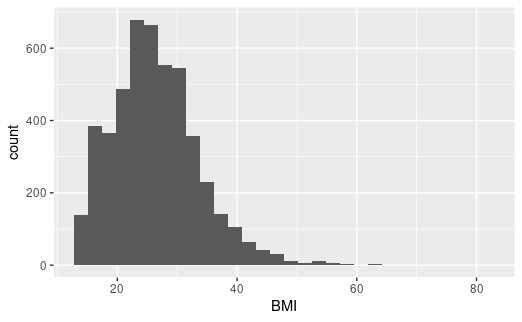

Change the bins

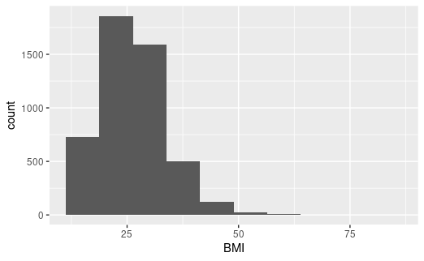

Divide by gender

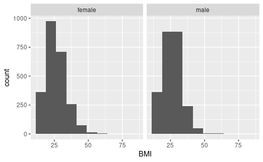

By sex and race

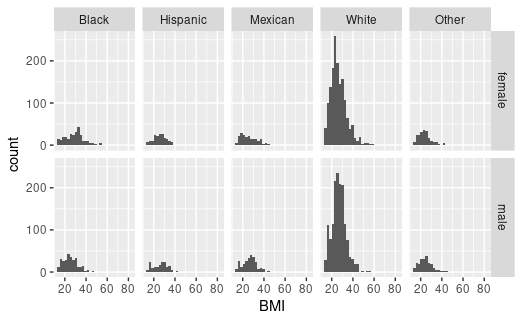

### Distribucions: geom_bar

Which island do penguins come from?

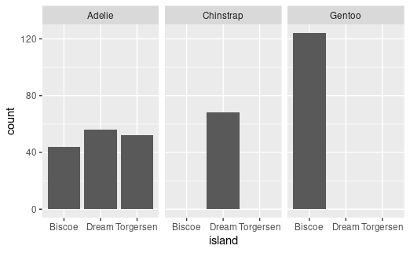

## ASSOCIATIONS

### Distribucions: geom_point

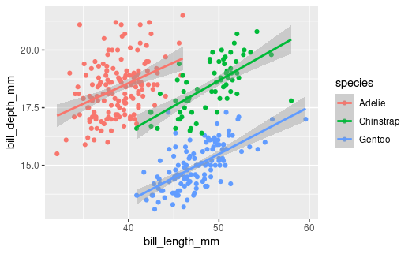

Explore the correlation of height and weight for the NHANES dataset

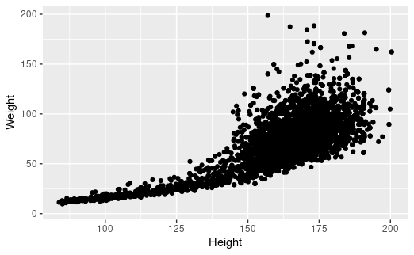

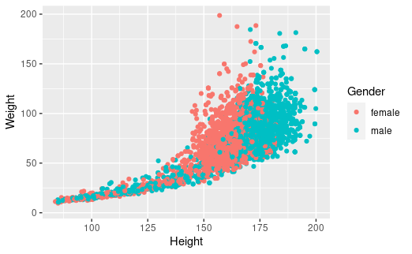

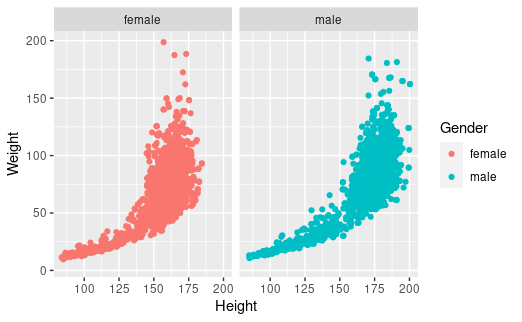

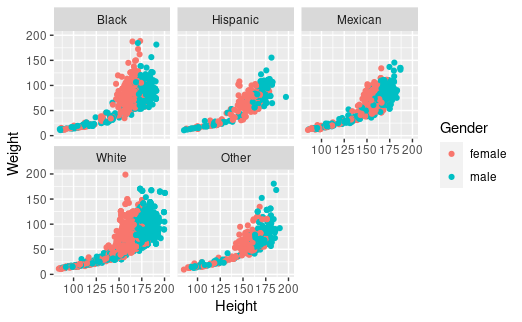

BMI by hours sleep

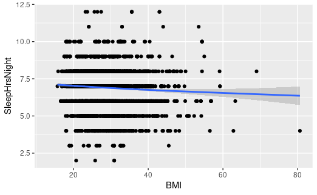

Head circumference and HHIncomeMid

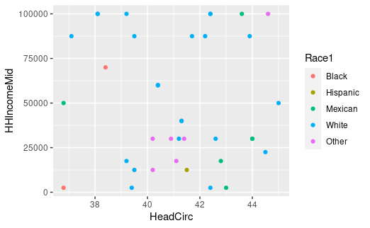

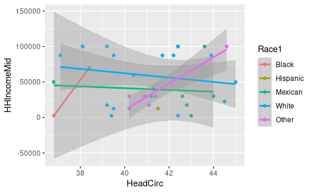

## COMPARISONS

One variable is factor and the another is continuous

Example: boddy_mass by species

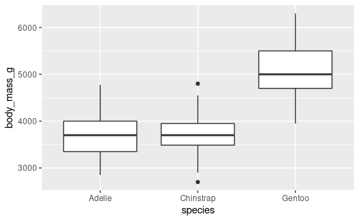

Explore the NHANES and identify differences in TotChol

and now by gender: hint: add a new aes as color or fill

## TRENDS

| dateRep | day | month | year | cases | deaths | countriesAndTerritories | geoId | countryterritoryCode | popData2019 | continentExp | Cumulative_number_for_14_days_of_COVID-19_cases_per_100000 |
| --- | --- | --- | --- | --- | --- | --- | --- | --- | --- | --- | --- |
| 28/10/2020 | 28 | 10 | 2020 | 113 | 7 | Afghanistan | AF | AFG | 38041757 | Asia | 3.025623 |
| 27/10/2020 | 27 | 10 | 2020 | 199 | 8 | Afghanistan | AF | AFG | 38041757 | Asia | 2.902074 |
| 26/10/2020 | 26 | 10 | 2020 | 65 | 3 | Afghanistan | AF | AFG | 38041757 | Asia | 2.718066 |
| 25/10/2020 | 25 | 10 | 2020 | 81 | 4 | Afghanistan | AF | AFG | 38041757 | Asia | 2.799555 |
| 24/10/2020 | 24 | 10 | 2020 | 61 | 2 | Afghanistan | AF | AFG | 38041757 | Asia | 2.586631 |
| 23/10/2020 | 23 | 10 | 2020 | 116 | 4 | Afghanistan | AF | AFG | 38041757 | Asia | 2.452568 |